# CherAnalysis

# Load

Load all subjects

```r
bdata <- read_csv("../gambling_clean_data.csv", show_col_types = F)
```

Load the model assignments

```r
assignments <- read_csv("../LL_model2.csv", show_col_types = FALSE)
```

Double check we have the right data:

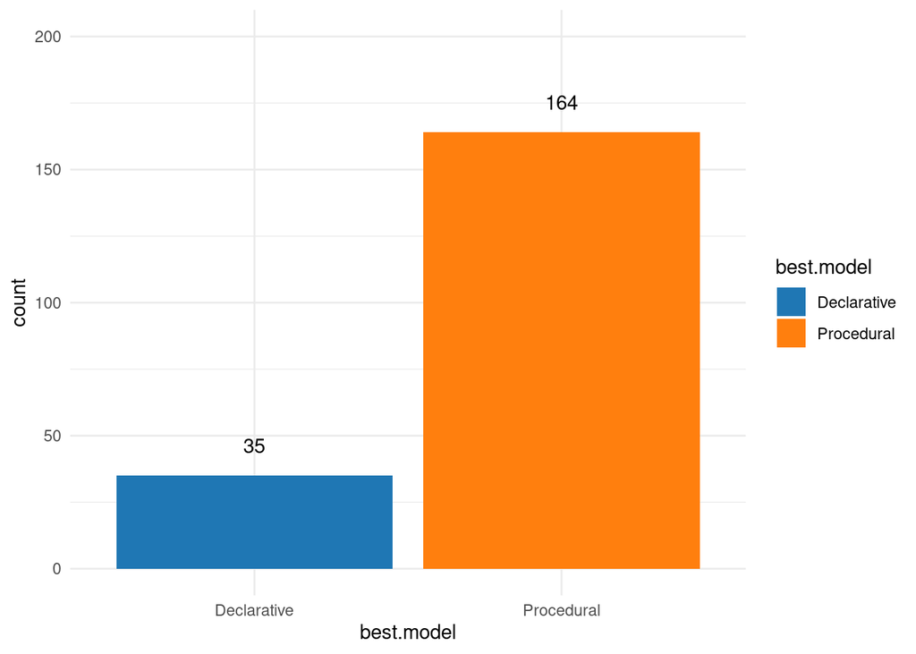

```r
ggplot(assignments, aes(x=best.model, fill=best.model)) +
  #geom_histogram(stat="count") +
  stat_count(binwidth=1) +
  ylim(c(0, 200)) +
  stat_count(binwidth=1, geom="text", aes(label=..count..), vjust=-1.5) +
  scale_fill_d3() +
  theme_minimal()
```

Merge the two, to make sure we have the same data

```r
full <- full_join(bdata, assignments, by="HCPID")
```

# Group Differences in Response Switch

```r
bytrial <- full %>%
  group_by(HCPID, TrialType) %>%
  filter(!is.na(ResponseSwitch)) %>%
  summarise(ResponseSwitch = mean(ResponseSwitch),
            RT = mean(RT),
            Model=mlv(best.model),
            deltaLL = mean(diff.LL)) %>%
  mutate(TrialType = recode(TrialType, Reward = "Win", Punishment = "Loss", Neutral = "Neutral"))
```

And now, let’s visualize

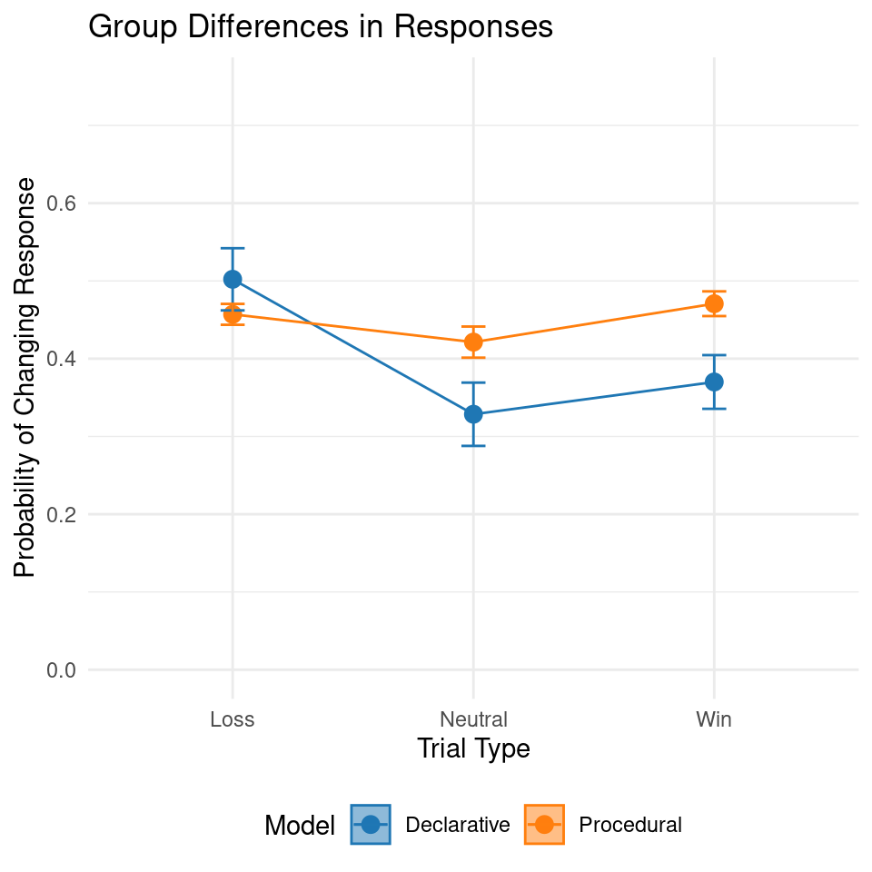

```r
ggplot(bytrial, aes(x=TrialType, y=ResponseSwitch, col=Model, fill=Model)) +
  stat_summary(geom="point", fun.data="mean_se", size=3) +
  stat_summary(geom="ribbon", fun.data = mean_se, alpha=0.5) +
  stat_summary(geom="errorbar", fun.data = mean_se, width=0.1) +
  stat_summary(geom="line", aes(group=Model), fun.data="mean_se") +
  coord_cartesian(ylim=c(0, .75)) +
  ylab("Probability of Changing Response") +
  xlab("Trial Type") +
  ggtitle("Group Differences in Responses") +
  scale_color_d3() +
  scale_fill_d3() +
  theme_minimal() +
  theme(legend.position = "bottom")
```

```r
ggsave("responseswitch.png", dpi=72)
```

The analysis reveal a main effect of Model (Group):

```r
mod_feedback <- glmer(ResponseSwitch ~ best.model *  TrialType + (1|HCPID),
                      family="binomial",
                      weights=abs(diff.LL),
                      data=filter(full, !is.na(ResponseSwitch)))
mod_feedback %>%
  tidy() %>%
  kable() %>%
  kable_styling(bootstrap_options=c("striped", "hover"))
```

| effect | group | term | estimate | std.error | statistic | p.value |
| --- | --- | --- | --- | --- | --- | --- |
| fixed | NA | (Intercept) | -1.1549844 | 0.3861142 | -2.9913027 | 0.0027779 |
| fixed | NA | best.modelProcedural | 0.8727832 | 0.3948299 | 2.2105294 | 0.0270684 |
| fixed | NA | TrialTypePunishment | 1.1306271 | 0.3873554 | 2.9188368 | 0.0035134 |
| fixed | NA | TrialTypeReward | 0.0411121 | 0.2956095 | 0.1390756 | 0.8893904 |
| fixed | NA | best.modelProcedural:TrialTypePunishment | -0.9472978 | 0.3885613 | -2.4379620 | 0.0147703 |
| fixed | NA | best.modelProcedural:TrialTypeReward | 0.0133671 | 0.2971817 | 0.0449796 | 0.9641236 |
| ran_pars | HCPID | sd__(Intercept) | 0.9543986 | NA | NA | NA |

```r
tab_model(mod_feedback)
```

|  | ResponseSwitch |  |  |
| --- | --- | --- | --- |
| Predictors | Odds Ratios | CI | p |
| (Intercept) | 0.32 | 0.15 – 0.67 | **0.003** |
| best model [Procedural] | 2.39 | 1.10 – 5.19 | **0.027** |
| TrialType [Punishment] | 3.10 | 1.45 – 6.62 | **0.004** |
| TrialType [Reward] | 1.04 | 0.58 – 1.86 | 0.889 |
| best model [Procedural] × TrialType [Punishment] | 0.39 | 0.18 – 0.83 | **0.015** |
| best model [Procedural] × TrialType [Reward] | 1.01 | 0.57 – 1.81 | 0.964 |
| Random Effects |  |  |  |
| σ<sup>2</sup> | 3.29 |  |  |
| τ<sub>00</sub> <sub>HCPID</sub> | 0.91 |  |  |
| ICC | 0.22 |  |  |
| N <sub>HCPID</sub> | 199 |  |  |
| Observations | 10927 |  |  |
| Marginal R<sup>2</sup> / Conditional R<sup>2</sup> | 0.072 / 0.273 |  |  |

# Group Differences in Persistance

Now, let’s look at the data by block:

```r
byblock <- full %>%
  group_by(HCPID, BlockTypeCoded) %>%
  summarise(Persistance = mean(ConsecSameResp),
            MaxPersistance = max(ConsecSameResp),
            RT = mean(RT),
            Model=mlv(best.model),
            deltaLL = mean(diff.LL)) %>%
  rename(Block = BlockTypeCoded) %>%
  mutate(Block = recode(Block, MostlyReward = "Mostly Wins", MostlyPunishment = "Mostly Losses"))
```

This is a visualization of the mean persistance by block and model.

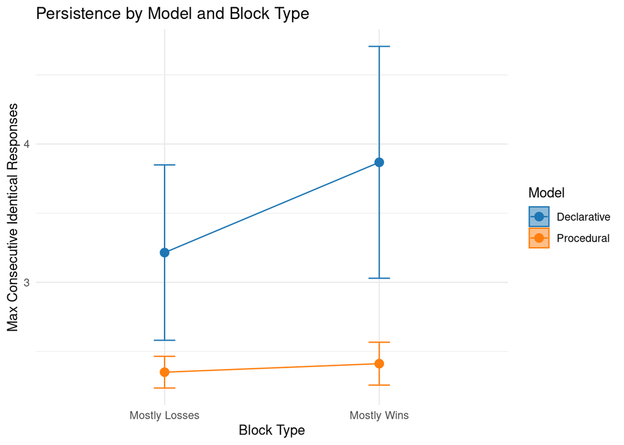

```r
ggplot(byblock, aes(x=Block, y=Persistance, col=Model, fill=Model)) +
  stat_summary(geom="point", fun.data="mean_se", size=3) +
  stat_summary(geom="ribbon", fun.data = "mean_se", alpha=0.5) +
  stat_summary(geom="errorbar", fun.data = "mean_se", width=0.1) +
  stat_summary(geom="line", aes(group=Model), fun.data="mean_se") +
  xlab("Block Type") +
  ylab("Max Consecutive Identical Responses") +
  ggtitle("Persistence by Model and Block Type") +
  scale_color_d3() +
  scale_fill_d3() +
  theme_minimal()
```

```r
ggsave("persistance.png", dpi=72)
```

To analyze this, we will use generalized linear model with a Poisson distribution. The choice of a Poisson distribution is given by the fact that the distribution of longest consecutive streaks (persistance) should obey a Poisson. Just in case, here is the actual distribution.

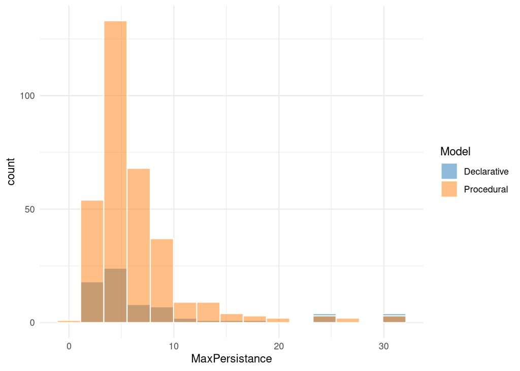

```r
ggplot(byblock, aes(x=MaxPersistance, fill=Model)) +
  geom_histogram(col="white", alpha=0.5, position = "identity", bins=15) +
  scale_fill_d3() +
  theme_minimal()
```

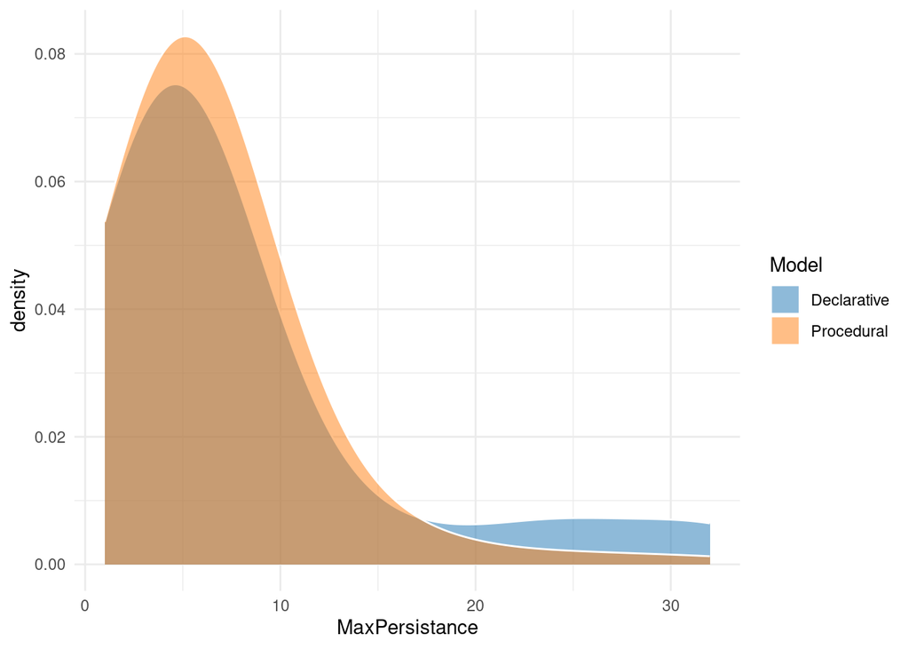

```r
ggplot(byblock, aes(x=MaxPersistance, fill=Model)) +
  geom_density(col="white", alpha=0.5, position = "identity", bw=4) +
  scale_fill_d3() +
  theme_minimal()
```

We first fit a Poisson model

```r
mod1 <- glm(MaxPersistance ~ Model * Block,  family="poisson",
            weights=abs(byblock$deltaLL),
            data=byblock)

mod1 %>%
  tidy() %>%
  kable() %>%
  kable_styling(bootstrap_options=c("striped", "hover"))
```

| term | estimate | std.error | statistic | p.value |
| --- | --- | --- | --- | --- |
| (Intercept) | 2.6331105 | 0.0336983 | 78.137718 | 0.0000000 |
| ModelProcedural | -0.6964377 | 0.0354577 | -19.641364 | 0.0000000 |
| BlockMostly Wins | 0.2501072 | 0.0449430 | 5.564989 | 0.0000000 |
| ModelProcedural:BlockMostly Wins | -0.1320499 | 0.0474306 | -2.784064 | 0.0053682 |

```r
tab_model(mod1)
```

|  | MaxPersistance |  |  |
| --- | --- | --- | --- |
| Predictors | Incidence Rate Ratios | CI | p |
| (Intercept) | 13.92 | 13.02 – 14.86 | **<0.001** |
| Model [Procedural] | 0.50 | 0.47 – 0.53 | **<0.001** |
| Block [Mostly Wins] | 1.28 | 1.18 – 1.40 | **<0.001** |
| Model [Procedural] × Block [Mostly Wins] | 0.88 | 0.80 – 0.96 | **0.005** |
| Observations | 398 |  |  |
| R<sup>2</sup> Nagelkerke | 0.911 |  |  |

It is possible to conceptualize the Max Persistance count as a Negative binomial

```r
mod2 <- MASS::glm.nb(MaxPersistance ~ Model * Block,
                     weights=abs(byblock$deltaLL),
                     data=byblock)

mod2 %>%
  tidy() %>%
  kable() %>%
  kable_styling(bootstrap_options=c("striped", "hover"))
```

| term | estimate | std.error | statistic | p.value |
| --- | --- | --- | --- | --- |
| (Intercept) | 2.6331105 | 0.0782222 | 33.661927 | 0.0000000 |
| ModelProcedural | -0.6964377 | 0.0806627 | -8.633952 | 0.0000000 |
| BlockMostly Wins | 0.2501072 | 0.1094813 | 2.284475 | 0.0223436 |
| ModelProcedural:BlockMostly Wins | -0.1320499 | 0.1129075 | -1.169541 | 0.2421859 |

```r
tab_model(mod2)
```

|  | MaxPersistance |  |  |
| --- | --- | --- | --- |
| Predictors | Incidence Rate Ratios | CI | p |
| (Intercept) | 13.92 | 11.97 – 16.26 | **<0.001** |
| Model [Procedural] | 0.50 | 0.42 – 0.58 | **<0.001** |
| Block [Mostly Wins] | 1.28 | 1.04 – 1.59 | **0.022** |
| Model [Procedural] × Block [Mostly Wins] | 0.88 | 0.70 – 1.09 | 0.242 |
| Observations | 398 |  |  |
| R<sup>2</sup> Nagelkerke | 0.450 |  |  |

Neither one first the data *too* well, TBH, but they do fit better than a normal distribution.

```r
gf <- goodfit(byblock$MaxPersistance, type= "nbinomial",method= "ML")
summary(gf)
```

```
##
##   Goodness-of-fit test for nbinomial distribution
##
##                       X^2 df     P(> X^2)
## Likelihood Ratio 333.9576 20 8.914914e-59
```

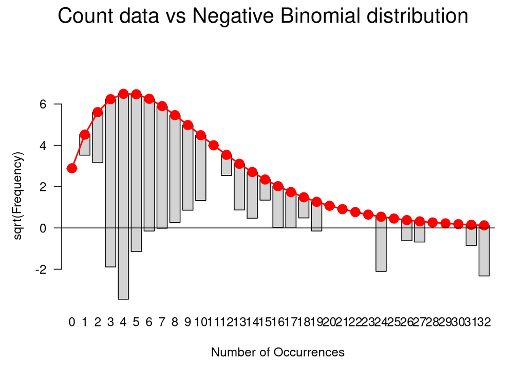

```r
plot(gf,main="Count data vs Negative Binomial distribution")
```

```r
gf <- goodfit(byblock$MaxPersistance, type= "poisson",method= "ML")
summary(gf)
```

```
##
##   Goodness-of-fit test for poisson distribution
##
##                       X^2 df      P(> X^2)
## Likelihood Ratio 756.7527 21 1.318867e-146
```

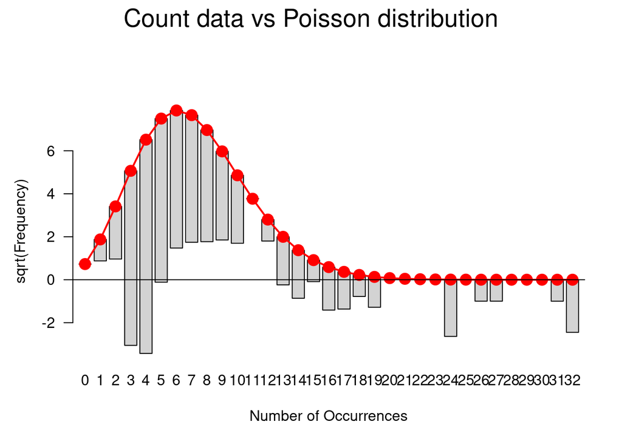

```r
plot(gf,main="Count data vs Poisson distribution")
```

# Group Differences in Response Times.

Then, we look at differences in RTs

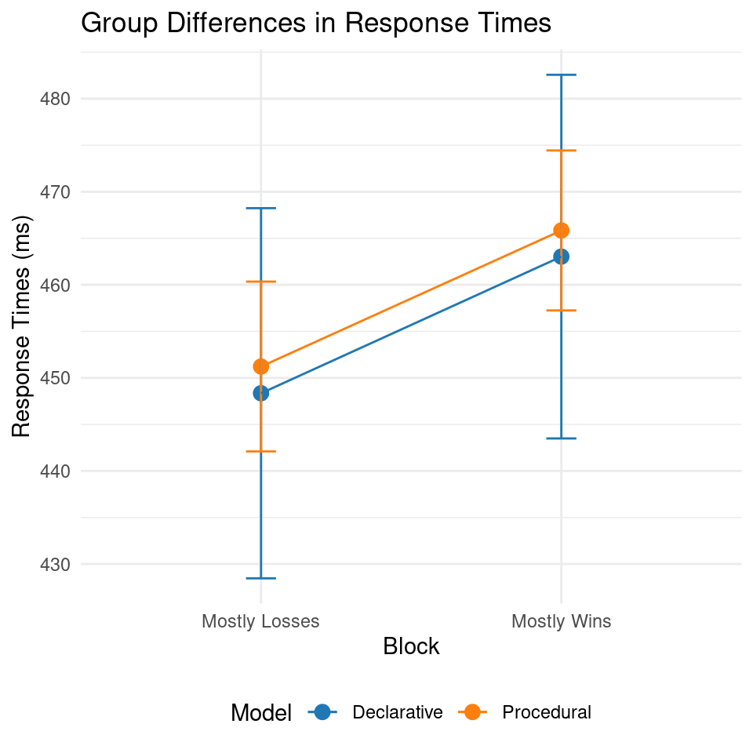

```r
ggplot(byblock, aes(x=Block, y=RT, col=Model, group=Model)) +
  stat_summary(geom="point", fun.data="mean_se", size=3) +
  stat_summary(geom="errorbar", fun.data = "mean_se", width=0.1) +
  stat_summary(geom="line", aes(group=Model), fun.data="mean_se") +
  ylab("Response Times (ms)") +
  ggtitle("Group Differences in Response Times") +
  scale_color_d3() +
  theme_minimal() +
  theme(legend.position = "bottom")
```

```r
ggsave("responsetimes.png", dpi=72)
```

This time, a linear mixed model does not reveal any effect, besides the effect of the win.

```r
mod3 <- glmer(log(RT) ~ Model * Block + (1|HCPID),
              family="Gamma",
              weights = abs(deltaLL),
              byblock)
tab_model(mod3)
```

|  | log(RT) |  |  |
| --- | --- | --- | --- |
| Predictors | Estimates | CI | p |
| (Intercept) | 1.18 | 1.18 – 1.18 | **<0.001** |
| Model [Procedural] | 1.00 | 1.00 – 1.00 | 0.473 |
| Block [Mostly Wins] | 1.00 | 1.00 – 1.00 | **0.002** |
| Model [Procedural] × Block [Mostly Wins] | 1.00 | 1.00 – 1.00 | 0.514 |
| Random Effects |  |  |  |
| σ<sup>2</sup> | 0.00 |  |  |
| τ<sub>00</sub> <sub>HCPID</sub> | 0.00 |  |  |
| ICC | 0.05 |  |  |
| N <sub>HCPID</sub> | 199 |  |  |
| Observations | 398 |  |  |
| Marginal R<sup>2</sup> / Conditional R<sup>2</sup> | 0.000 / 0.050 |  |  |